# Tree models, neural networks, and SGD

Adapted from the course book: Tree Models, Neural Networks, Gradient Descent

Vadim Sokolov

George Mason University

## Plan

- Trees: splitting, pruning, classification trees, bagging, random forests, boosting
- Neural networks: layers, activations, worked examples
- Gradient descent: learning rate, SGD, automatic differentiation, momentum and Adam
- All figures and formulas are from the book

# Tree models

## Trees as nested if-else rules

- A predictive tree is a nested sequence of if-else statements that map an input $x$ to a predicted output $y$
- Each statement checks one feature of $x$ and sends the data left or right
- At the end of the branch, a single value of $y$ is predicted
- Prediction: traverse from the root to a leaf following the conditions

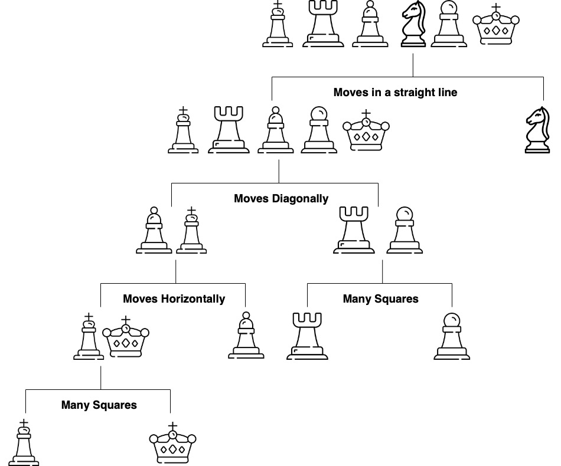

Elementary tree scheme; visualization of the splitting process.

## Three components of building a tree

1. Splitting: divide the training data into subsets by the value of a single feature, as homogeneous as possible
2. Stopping: decide when to stop splitting, as accurate as possible without overfitting
3. Pruning: remove nodes that do not improve accuracy, to get a smaller tree that predicts new data as well as the full one
- At each step choose a feature index $j$ and a split location
- Regression trees: best split minimizes the sum of squared errors
- Classification trees: best split minimizes the Gini impurity

## Example data: diamonds

- 53,940 diamonds, 10 variables

| Variable | Description | Values |
| --- | --- | --- |
| `carat` | Weight of the diamond | Numeric |
| `cut` | Quality of the cut | Fair, Good, Very Good, Premium, Ideal |
| `color` | Color of the diamond | J, I, H, G, F, E, D |
| `clarity` | Clarity of the diamond | I1, SI2, SI1, VS2, VS1, VVS2, VVS1, IF |
| `price` | Price in US dollars | Numeric |

- Also in the data: `depth`, `table`, `x`, `y`, `z`

## Regression tree for diamond price

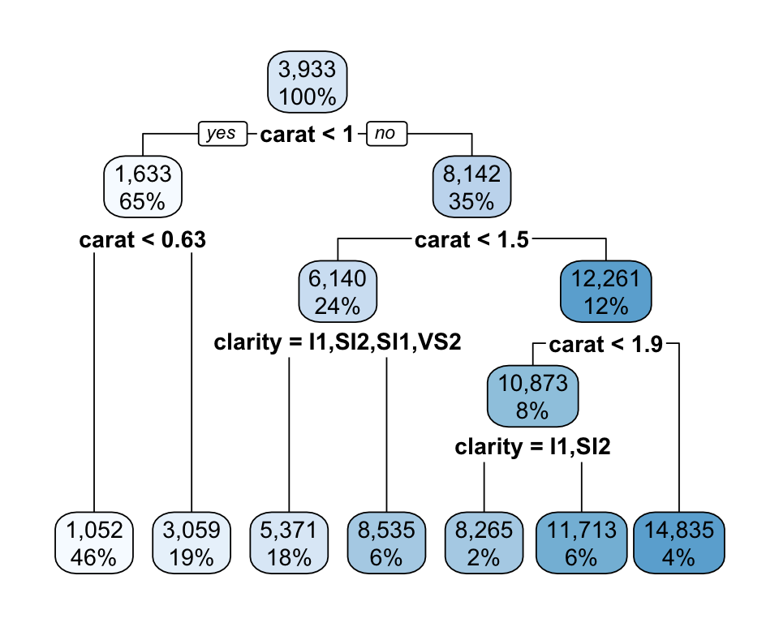

Regression tree for price on carat and clarity. Each node shows the mean price and the share of diamonds.

## Prediction regions of the tree

- Each tile is one combination of carat and clarity, colored by predicted price
- Carat is the strongest predictor: vertical bands of similar shades
- The tree creates rectangular regions with sharp boundaries

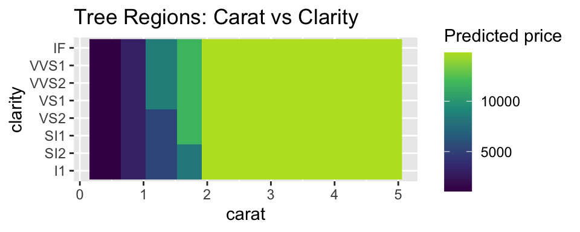

Predicted price of the two-predictor tree on a grid of carat and clarity.

## Building a tree via recursive binary splitting

- Predictor space is divided into $J$ non-overlapping boxes $R_1, \ldots, R_J$
- Prediction in box $R_j$ is the mean of the training responses in it
  $$f(x) = \bar y_j, \text{ for } x \in R_j, \text{ where } \bar y_j = \text{Average}(y_i \mid x_i \in R_j)$$
- Goal: minimize the total residual sum of squares (RSS)
  $$\mathrm{RSS} = \sum_{j=1}^J\sum_{i \in R_j}(y_i - \bar{y}_j)^2 \rightarrow \mathrm{minimize}$$
- Considering every partition into $J$ boxes is NP-hard, so use the top-down CART algorithm

## The splitting rule

- At each step choose the variable $j$ and the split point $s$
  $$R_1(j, s) = \{x\mid x_j < s\} \mbox{ and } R_2(j, s) = \{x\mid x_j \ge s\}$$
- Regression tree: minimize
  $$\min_{j,s}\left[ \sum_{i:x_i\in R_1}(y_i - \bar{y}_1)^2 + \sum_{i:x_i \in R_2}(y_i - \bar{y}_2)^2\right]$$
- Here $\bar y_1$ and $\bar y_2$ are the mean responses in $R_1$ and $R_2$
- Every observed input point belongs to a single region

## Pruning: taming an overfit tree

- $n$ regions: works like one-nearest neighbor. One region: every prediction is the average of the $y$’s
- Number of regions controls complexity on the variance-bias scale
- Grow an extensive tree $T_0$, then trim to a subtree, with size chosen by cross-validation
- Cost complexity (weakest link) pruning: for each $\alpha \ge 0$ find the subtree $T \subset T_0$ that minimizes
  $$\sum_{m=1}^{|T|}\sum_{i:x_i\in R_m}(y_i - \bar{y}_m)^2 + \alpha |T|$$
- $|T|$ is the number of leaves, $\bar y_m$ the mean in region $R_m$, $\alpha$ the tuning parameter
- Raising $\alpha$ from zero prunes branches in sequence; pick $\hat \alpha$ by cross-validation, then take the matching subtree from the full data

## Boston housing: pruned tree for medv on lstat

- `medv`: median value of owner-occupied homes in $1000s. `lstat`: lower status of the population percent
- Grow a big tree, then prune it down to one with 7 leaves

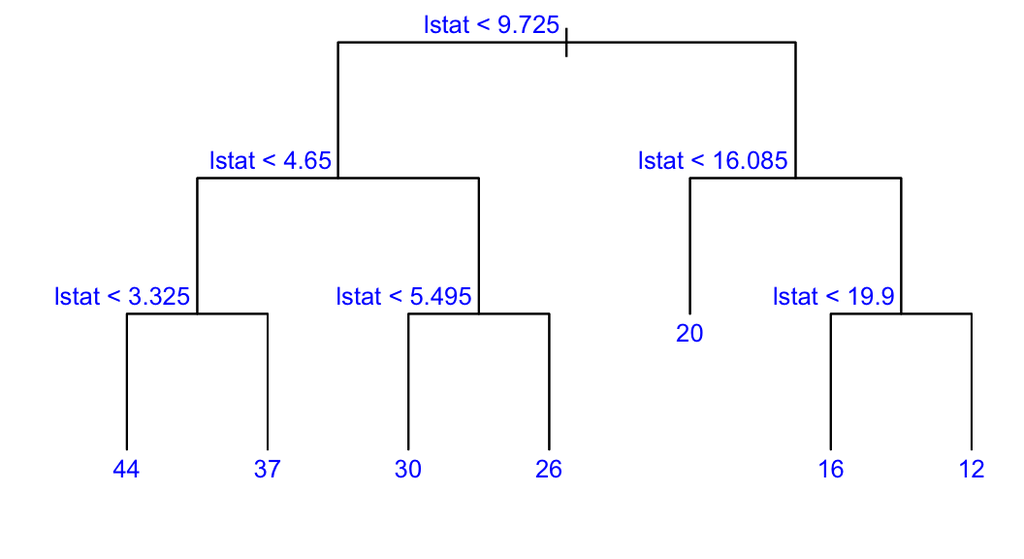

Pruned tree.

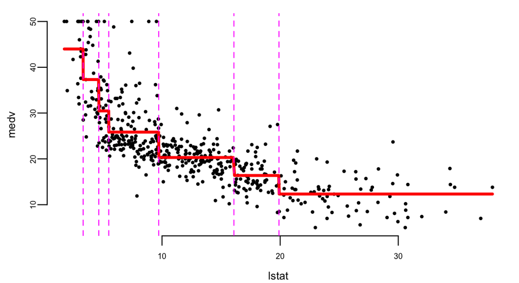

Step function fit, with cutpoints as dashed lines.

## Two predictors: partition and fitted surface

- `dis`: weighted mean of distances to five Boston employment centres
- Tree for `medv` on `dis` and `lstat`

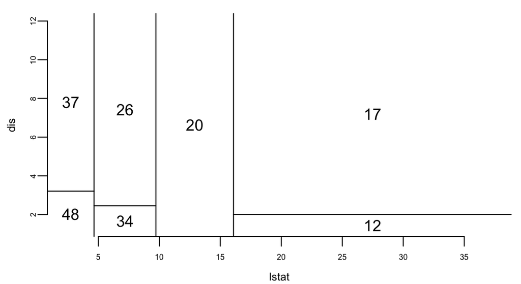

Partition of the (dis, lstat) plane.

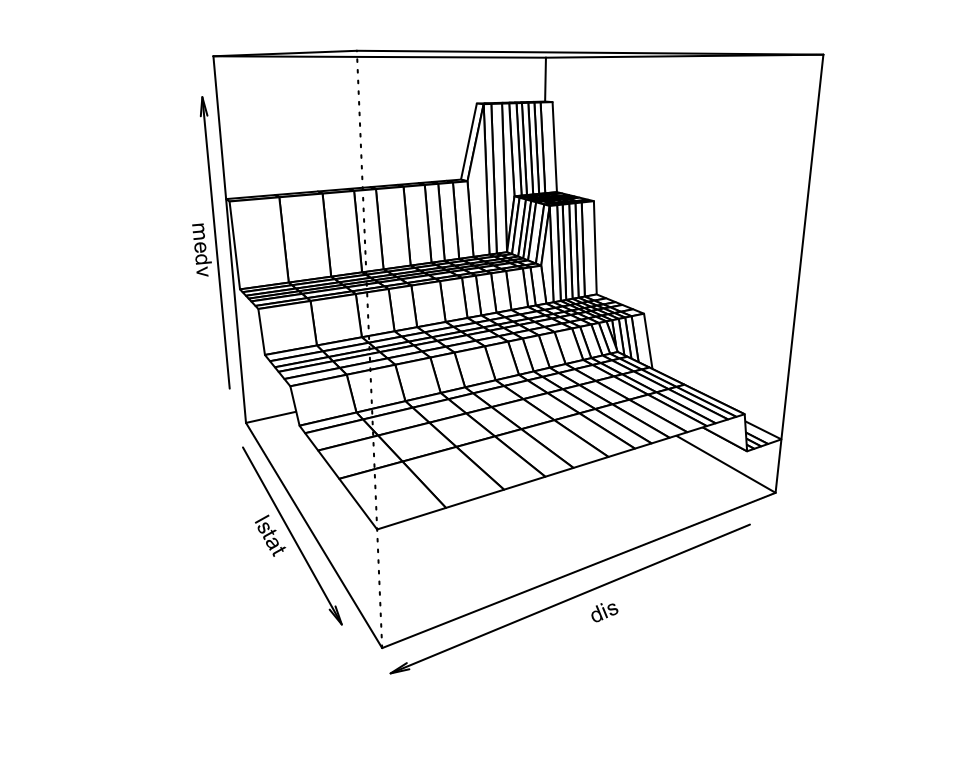

Perspective plot of the tree prediction of medv over dis and lstat.

## Classification trees

- Prediction by majority vote within the region
- $p_{mk}$: proportion of class $k$ in region $m$, with $N_m$ observations in the region and $R_m$ the region
  $$p_{mk} = \dfrac{1}{N_m}\sum_{x_i \in R_m} I(y_i=k)$$
- $p_m$: proportion of the most frequent class. $E_m$: error rate, the share not in the majority class
  $$p_m = \max_k p_{mk},~~~ E_m = 1-p_m$$
- Predicted class probability
  $$P(y=k \mid x) = \sum_{m=1}^J p_{mk} I(x \in R_m)$$

## Gini index and cross-entropy

- Example: 400 observations in each of two classes. Tree A has regions (300,100) and (100,300). Tree B has regions (200,400) and (200,0)
- Both have misclassification rate 0.25, but B is more desirable: region (200,0) is pure
- Gini index and cross-entropy are more sensitive to node purity
- Gini index ($K$ classes): a variance across classes, small if all $p_{mk}$ are close to zero or one
  $$G_m = \sum_{k=1}^K p_{mk}(1-p_{mk})$$
- Cross-entropy (deviance): near zero if all $p_{mk}$ are near zero or one
  $$D_m = -\sum_{k=1}^Kp_{mk}\log p_{mk}$$
- Gini and cross-entropy lead to similar results

## Example: classifying diamond quality

- Binary problem: “Ideal” cut against others, from price, carat and clarity

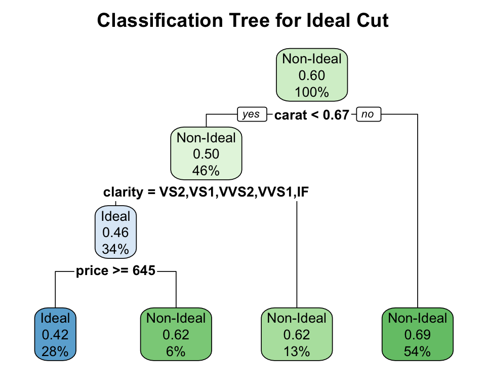

Classification tree for an Ideal cut. Each node shows the predicted class, the probability of the Non-Ideal class and the share of diamonds.

## Ensemble methods

- Two alternatives to pruning: Random Forests (averaging many trees) and Boosting (sequentially fitting trees to residuals)
- The variance of the average is lower than the variance of individual models
- Combine $B$ models $f_1(x),\ldots,f_B(x)$
  $$f_{avg}(x) = \dfrac{1}{B}\sum_{b=1}^Bf_b(x)$$
- Combining models fights overfitting. Cost: harder to interpret than a single tree

## Bagging

- Treat the sample as the population and draw with replacement
- Take $B$ bootstrap samples of the same size as the training data
- Fit a large tree to each sample
- Combine the $B$ trees: average for numeric $y$, vote or average the probabilities for categorical $y$
- Each bootstrap sample leaves out about 37% of the observations, since $(1-1/n)^n \to e^{-1}$
- Out-of-bag (OOB) prediction uses only trees that did not see the observation. OOB error estimates test error without a validation set

## Bagging on Boston: 10, 500 and 5,000 trees

- With 10 trees the fit is too jumbly (high variance). A few points were in every bootstrap sample, so they have no out-of-bag prediction and the curve skips them
- With 500 and 5,000 trees the fit is smoother and very similar
- Averaging trees with different cutpoints gives a step function with very many small steps

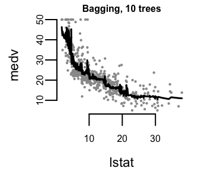

10 trees.

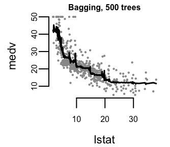

500 trees.

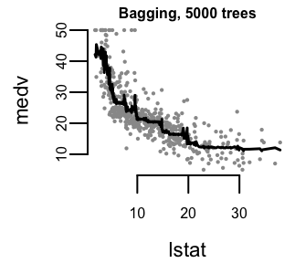

5,000 trees.

## Random forest

- In bagging the trees become correlated: most use the most influential predictor in the top split, so a $1/B$ reduction in variance is not achieved
- Random forests decorrelate the trees: at each split a random sample of $m$ of the $p$ predictors is the candidate set, different for each split
- Typical $m$: $\sqrt{p}$ for classification, $p/3$ for regression

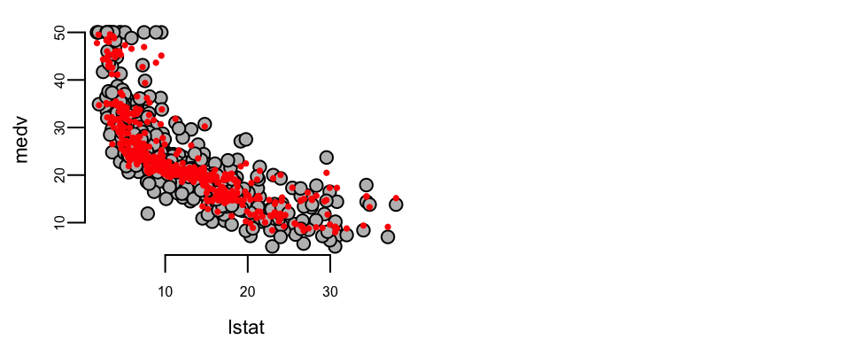

Random Forest fit (red) on all predictors, in-sample, plotted against lstat.

## Variable importance

- Right panel (`IncNodePurity`): total decrease in loss (residual sum of squares) due to splits over a predictor, averaged over all trees
- Left panel (`%IncMSE`): permutation importance, the increase in out-of-bag mean squared error when the predictor is permuted, averaged over trees and divided by its standard deviation

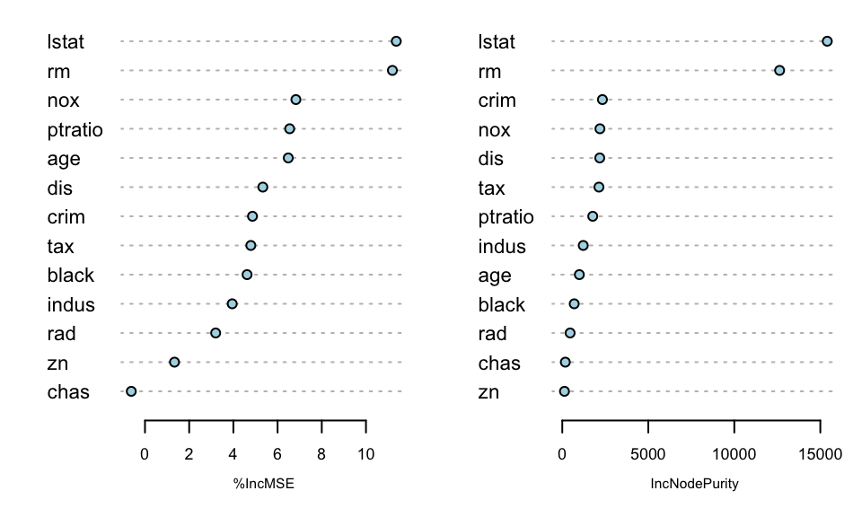

Variable importance in a Random Forest for the Boston data: permutation importance (left) and total decrease in node impurity (right).

## Boosting

1. Fit a single intentionally weak tree
2. Examine the residuals, the part of $y$ the tree does not explain
3. Fit a new tree to the residuals
4. Shrink it by a learning rate $\lambda$ and add it to the previous trees
5. Repeat. The final model is the sum of all shrunk trees
- The key idea: improve the model by focusing on what it does not explain yet

## Boosting as gradient descent in function space

- Minimize a loss $\mathcal{L}$ over $n$ observations; for regression $\mathcal{L}(y_i , \theta_i ) = \frac{1}{2}(y_i - \theta_i )^2$
  $$\mathrm{minimize}_{\beta \in \mathbb{R}^B} \sum_{i=1}^n \mathcal{L} \left(y_i, \sum_{b=1}^B \beta_b \cdot T_b(x_i)\right)$$
- Here $T_b$ are trees and $\beta_b$ their weights. Start from $\theta^{(0)} = T_0$, a single tree. Repeat:
  $$g_i = \left.\left[\frac{\partial \mathcal{L}(y_i, \theta_i)}{\partial \theta_i}\right]\right|_{\theta_i = \theta_i^{(k-1)}},\ i=1,\ldots,n$$
  $$\mathrm{minimize}_{\text{trees }T} \sum_{i=1}^n (-g_i - T(x_i))^2$$
  $$\theta^{(k)} = \theta^{(k-1)} + \lambda \cdot T_k$$
- $g$ is the gradient at the latest prediction; $T_k$ is the tree closest to $-g$

## Boosting algorithm

1. Set $\hat{f}(x)=0$ and $r_i=y_i$ for all $i$ in the training set
2. For $b=1,2,\ldots,B$ repeat:
   - Fit a tree $\hat{f}^b$ with $d$ splits (interactions) to the data $(X, r)$
   - Update $\hat{f}(x) \leftarrow \hat{f}(x) +\lambda \hat{f}^b(x)$
   - Update the residuals $r_i \leftarrow r_i - \lambda \hat{f}^b(x_i)$
3. Output
   $$\hat{f}(x) = \sum_{b=1}^B \lambda \hat{f}^b(x)$$
- $\lambda$: learning rate or shrinkage, e.g., 0.01 or 0.1. A small value prevents adapting too quickly to outliers or noise
- Example: 5,000 trees, interaction depth 4, `gbm` default $\lambda = 0.1$

## Partial dependence

- Partial dependence plots show the effect of the two most influential variables, `rm` and `lstat`, on `medv` after integrating out the others

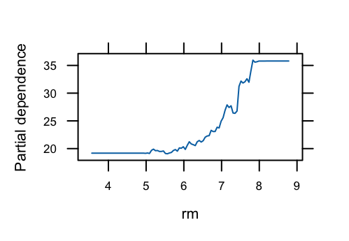

rm.

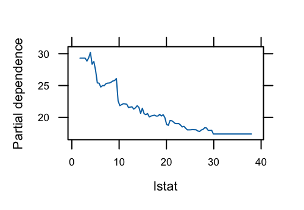

lstat.

## Boosting versus random forests

- Boosting: often more accurate by correcting residuals, but more prone to overfitting and noise. Needs careful tuning of $\lambda$ and $B$
- Random forests: more robust out of the box, easier to parallelize (trees are independent), less prone to overfitting, may not reach the peak accuracy of well-tuned boosting

# Neural networks

## Neural networks: the deep predictor

- Deep learning extends generalized linear models with multiple layers of nonlinear transformations
- Classical methods are wide and shallow. Deep learning is deep and narrow: many successive transformations, fewer units per layer
- Let $f_1 , \ldots , f_L$ be univariate activation functions for the $L$ layers. A nonlinear activation of an affine transformation:
  $$f_l^{W,b}(Z) = f_l ( W_l Z + b_l )$$
- $W_l$ is the weight matrix with $N_l$ rows (hidden units of layer $l$), $b_l$ the bias. The deep predictor is the composite map
  $$\hat{Y}(X) = F(X) = \left ( f_L^{W_L,b_L} \circ \ldots \circ f_1^{W_1,b_1} \right ) ( X)$$

## Layers and hidden features

- $Z^{(l)}$ is the $l$th layer, $X = Z^{(0)}$
  $$\begin{aligned}
  \hat{Y} (X) & = W^{(L)} Z^{(L)} + b^{(L)} \\
  Z^{(1)} & = f^{(1)} \left ( W^{(0)} X + b^{(0)} \right ) \\
  Z^{(2)} & = f^{(2)} \left ( W^{(1)} Z^{(1)} + b^{(1)} \right ) \\
  \ldots & \\
  Z^{(L)} & = f^{(L)} \left ( W^{(L-1)} Z^{(L-1)} + b^{(L-1)} \right )
  \end{aligned}$$
- $W^{(l)}$: weight matrix. $b^{(l)}$: bias terms that shift the activation functions
- $Z^{(l)}$ are hidden features (latent representations) extracted from the data
- Layers $1$ to $L$ are hidden layers. $L$ is the depth

## Products and maxima from univariate functions

- Interactions and thresholds are built from univariate functions of linear projections of the input
  $$x_1x_2 = \frac{1}{4} ( x_1+x_2 )^2 - \frac{1}{4} (x_1-x_2)^2$$
  $$\max(x_1,x_2) = \frac{1}{2} ( x_1+x_2 ) + \frac{1}{2} | x_1-x_2 |$$
- This is precisely what neural networks do
- ReLU compositions: with $x^+ = \max(x,0)$,
  $$( f_{x_1} \circ \ldots \circ f_{x_k} ) (0) = ( x_1 + ( x_2 + \ldots + ( x_{k-1} + x_k^+ )^+ )^+ )^+ = \max_{1 \leq j \leq k} ( x_1 + \ldots + x_j )^+$$
- A composition of such maps reduces to a single maximum of partial sums

## Classification: from logistic regression to four lines

- Simulated data: the inner cluster is one class, the outer ring the other
- Logistic regression fails because the data are not linearly separable. Multiple lines can separate the data; apply the logistic function to each line

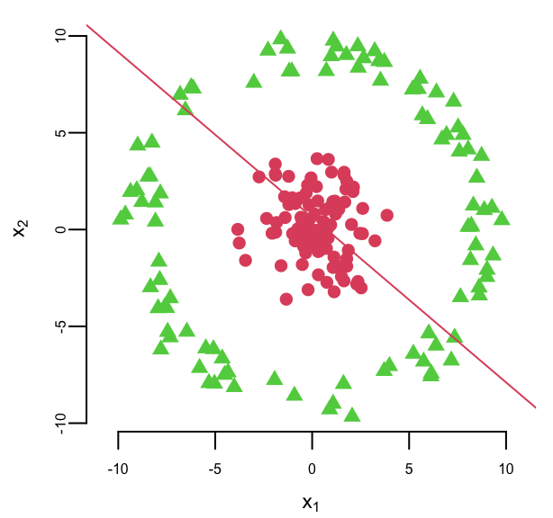

Logistic regression boundary on the circle data.

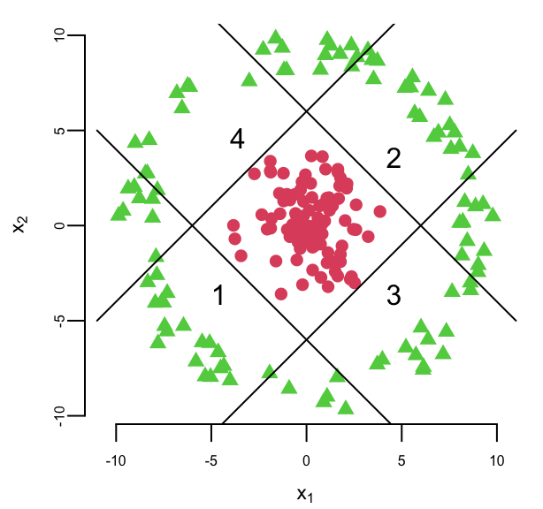

Four lines that separate the inner cluster from the outer ring.

## First layer and output layer

- First layer: a 2-dimensional input $x$ gives a 4-dimensional feature vector $z$
  $$z = \sigma(Wx + b), ~ W = \begin{bmatrix} 1 & 1 \\ -1 & -1 \\ -1 & 1 \\ 1 & -1 \end{bmatrix}, ~ b = \begin{bmatrix} 6 \\ 6 \\ 6 \\ 6 \end{bmatrix}, ~ \sigma(z) = \frac{1}{1+e^{-z}}$$
- Output layer: logistic regression on the feature vector; $\hat y$ is the probability of the inner class
  $$\hat{y} = \sigma(w^\top z + b), ~ w = \begin{bmatrix} 1 \\ 1 \\ 1 \\ 1 \end{bmatrix}, ~ b = -3.1$$

## Predicted probability on a grid

- Evaluated on a grid of 10,000 points (100 values for each of the two inputs)

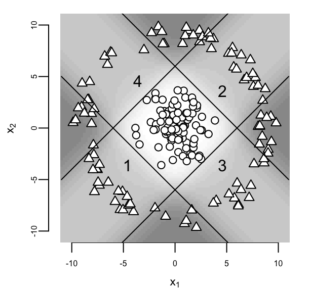

Predicted probability of the inner class on a grid, with the data and the four lines.

## Regression: noisy quadratic

- Simulate from
  $$y = 0.5 + 0.3x^2 + \epsilon, ~ \epsilon \sim N(0,0.02^2)$$
- One hidden layer with 3 units and ReLU, one linear output unit, 8 parameters (1 shared hidden bias, 3 weights, 1 output bias, 3 output weights)
- Fit by BFGS, minimizing the sum of squared errors

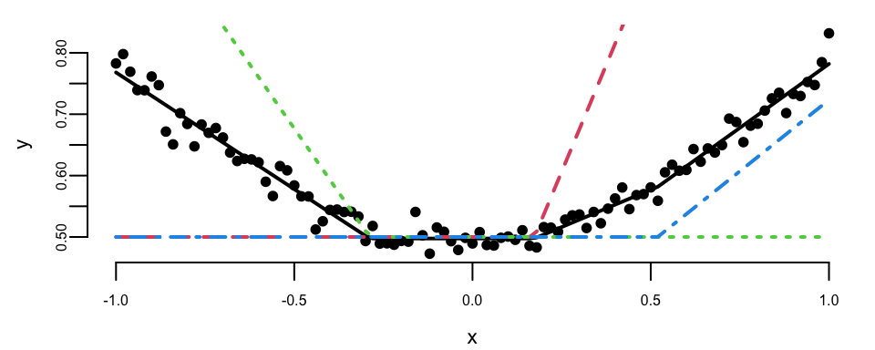

Noisy quadratic function approximated by a neural network with ReLU activation function. Solid: network. Broken: hidden units, shifted up by 0.5.

## Regression: tanh activation

- The network did not need an explicit quadratic term; it discovered the structure from the data

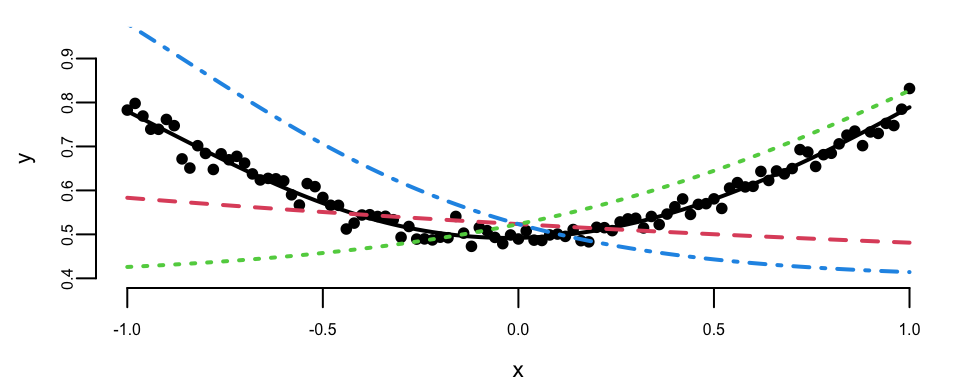

Noisy quadratic function approximated by a neural network with tanh activation function. The broken lines are the hidden units, rescaled.

## Learning an interaction

- Data-generating process, with $x_1, x_2$ independent uniform on $(-1, 1)$, 200 observations
  $$y = 0.5 + 0.1x_1 + 0.2x_2 + 0.5x_1x_2+ \epsilon, ~ \epsilon \sim N(0,0.02^2)$$
- Two inputs, two hidden units with tanh. The model approximately learns the interaction

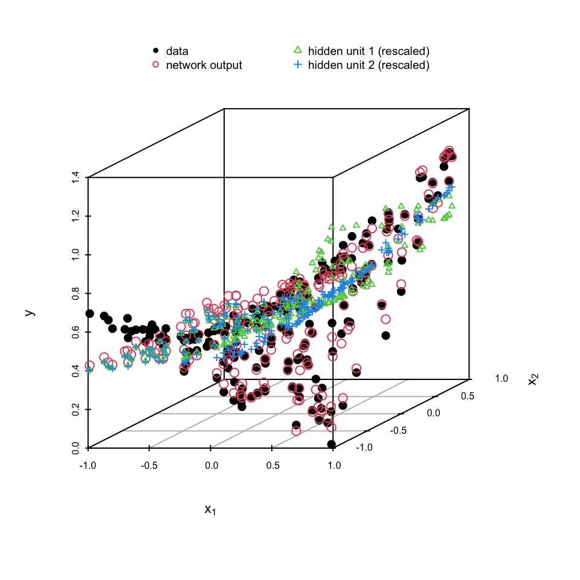

Interaction data, network output and rescaled hidden units.

## Activation functions and ReLU

- Output layer: sigmoid for binary output, no activation for continuous output
- Hidden layers: most common are tanh and ReLU
  $$\tanh(z) = \frac{e^z - e^{-z}}{e^z + e^{-z}}, ~~ \tanh(z) = 2\,\sigma(2z) - 1$$
- Sigmoid and tanh saturate at extreme inputs, where the gradient is nearly zero. Gradients multiply across layers and become negligible: the vanishing gradient problem

$$\text{ReLU}(z) = \max(0,z), ~~ \text{ReLU}'(z) = \begin{cases} 0 & \text{if } z < 0 \\ 1 & \text{if } z > 0 \end{cases}$$

- ReLU is piecewise linear, efficient, the most commonly used activation. Not differentiable at $z=0$. Softplus $\log(1+e^z)$ is a smooth ReLU. Leaky ReLU: $\max(0.1z, z)$

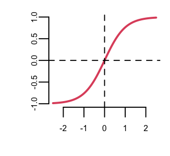

tanh

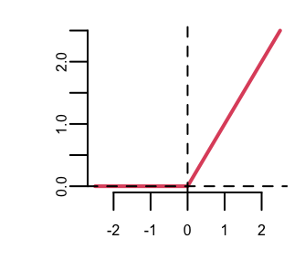

ReLU

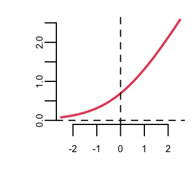

softplus

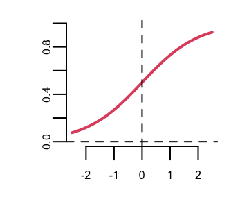

sigmoid

# Gradient descent

## Gradient descent

- Second-order methods (least squares, BFGS) use the Hessian and do not scale to millions of parameters. First-order methods need only the gradient
- Parameter estimation is optimization, with $l$ the negative log-likelihood and $\theta$ the parameter vector
  $$\min_{\theta} l(\theta) := -\dfrac{1}{n} \sum_{i=1}^n \log p(y_i \mid x_i, \theta)$$
- Start at $\theta^{0}$; at iteration $t$, with learning rate $\alpha_t$,
  $$\theta^{t+1} = \theta^t - \alpha_t \nabla l(\theta^t), ~~ \nabla l(\theta^t) = \left(\frac{\partial l}{\partial \theta_0}, \ldots,\frac{\partial l}{\partial \theta_p}\right)$$
- The negative gradient points in the direction of steepest descent

## Non-differentiable points

- Derivative: $l'(\theta) = \lim_{h \to 0} \frac{l(\theta+h) - l(\theta)}{h}$, the slope of the tangent line
- $f(\theta) = |\theta|$ has a sharp corner at zero: derivative $+1$ for $\theta > 0$, $-1$ for $\theta < 0$, undefined at zero
- ReLU $\max(0, x)$ has such a point, yet gradient descent still works:
  - the probability of landing exactly on it is zero for continuous distributions
  - at a kink, software uses one of the one-sided derivatives

## Learning rate

- Too small: slow convergence. Too large: divergence or oscillation
- For $l(\theta) = \theta^2$ from $\theta_0 = 2$: $\alpha = 0.5$ converges in one step, $\alpha = 0.25$ more slowly, $\alpha = 1$ overshoots

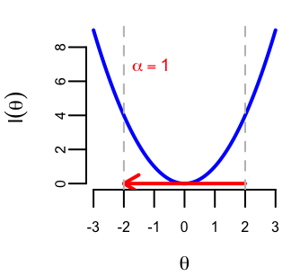

$\alpha=1$ (too large)

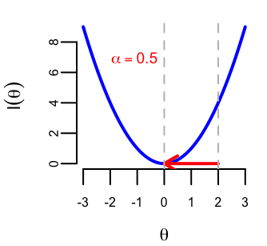

$\alpha=0.5$ (ideal)

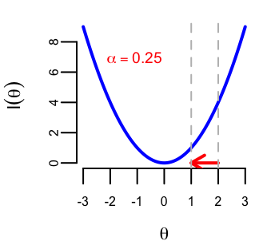

$\alpha=0.25$ (working)

## Deep learning and least squares

- Training data $D = \{x_i,y_i\}_{i=1}^n$, model $f_{\theta}(x)$, loss is the negative log-likelihood
  $$l(\theta) = - \sum_{i=1}^n \log p(y_i \mid x_i, \theta)$$
- Regression: $y_i = f_{\theta}(x_i) + \epsilon_i, ~ \epsilon_i \sim N(0,\sigma^2)$. Dropping the constant $n\log(\sigma\sqrt{2\pi})$,
  $$l(\theta) \propto \sum_{i=1}^n (y_i - f_{\theta}(x_i))^2$$

## Example: linear regression by gradient descent

- A degenerate neural network: one layer, no hidden units, identity activation
- Model $y_i = \theta_0 + \theta_1 x_i + \epsilon_i$, or $y = X \theta + \epsilon$, with design matrix $X = [1 ~ x]$ (first column all ones)
- Data: `iris`, $y =$ `Petal.Length`, $x =$ `Petal.Width`
  $$l(\theta) = \sum_{i=1}^n (y_i - \theta_0 - \theta_1 x_i)^2, ~~ \nabla l(\theta) = -2 X^\top (y - X \theta)$$

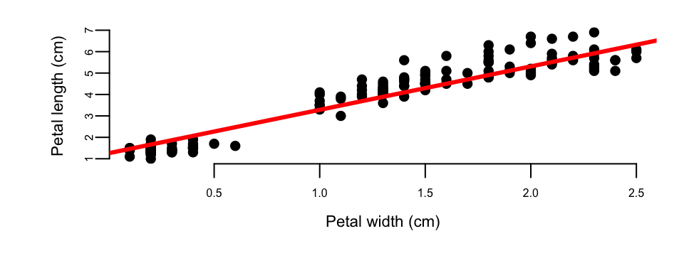

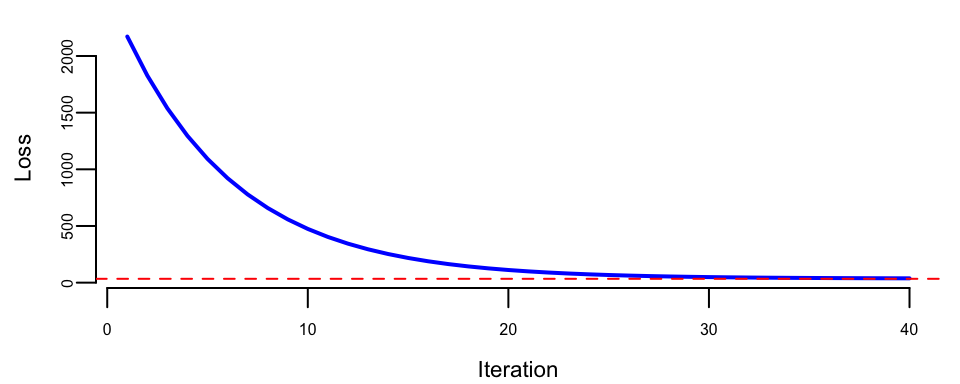